# Illustration of simple problematic posteriors

Author

Aki Vehtari

Published

2021-06-10

Modified

2026-08-20

This notebook includes the code for Bayesian Workflow book Section 12.3 *Failure modes and steps forward*.

# 1 Introduction

This case study demonstrates using simple examples the most common failure modes in Markov chain Monte Carlo based Bayesian inference, how to recognize these using the diagnostics, and how to fix the problems.

Define LaTeX commands **Load packages**

````r
library(rprojroot)
root <- has_file(".Bayesian-Workflow-root")$make_fix_file()
library(cmdstanr)
library(posterior)
options(pillar.neg = FALSE,
        pillar.subtle = FALSE,
        pillar.sigfig = 2)
options(width = 90)
library(tidyr)
library(dplyr)
library(ggplot2)
library(bayesplot)
library(RColorBrewer)
theme_set(bayesplot::theme_default(base_family = "sans", base_size = 14))
library(latex2exp)
library(patchwork)
set1 <- RColorBrewer::brewer.pal(7, "Set1")
SEED <- 48927 # set random seed for reproducibility

print_stan_file <- function(file) {
  code <- readLines(file)
  if (isTRUE(getOption("knitr.in.progress")) &
        identical(knitr::opts_current$get("results"), "asis")) {
    # In render: emit as-is so Pandoc/Quarto does syntax highlighting
    block <- paste0("```stan", "\n", paste(code, collapse = "\n"), "\n", "```")
    knitr::asis_output(block)
  } else {
    writeLines(code)
  }
}
````

# 2 Improper posterior

An unbounded likelihood without a proper prior can lead to an improper posterior. We recommend to always use proper priors (integral over a proper distribution is finite) to guarantee proper posteriors.

A commonly used model that can have unbounded likelihood is logistic regression with complete separation in data.

## 2.1 Data

Univariate continous predictor $x$, binary target $y$, and the two classes are completely separable, which leads to unbounded likelihood.

```r
set.seed(SEED + 4)
M <- 1
N <- 10
x <- matrix(sort(rnorm(N)), ncol = M)
y <- rep(c(0, 1), each = N / 2)
data_logit <- list(M = M, N = N, x = x, y = y)
```

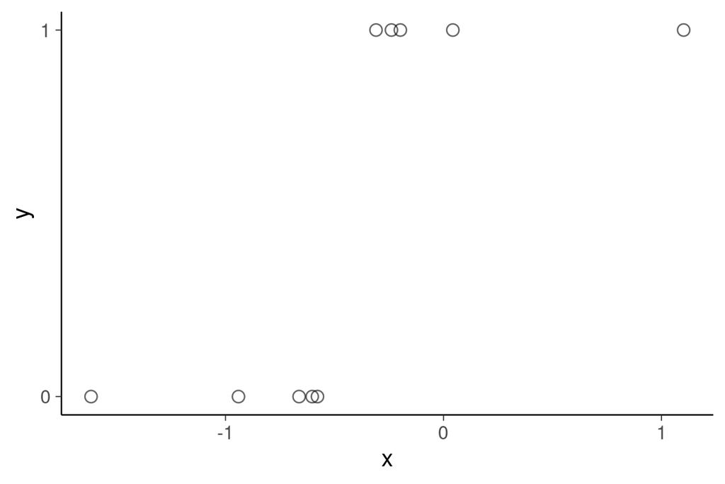

Figure 1

```r
data.frame(data_logit) |>
  ggplot(aes(x, y)) +
  geom_point(size = 3, shape = 1, alpha = 0.6) +
  scale_y_continuous(breaks = c(0, 1))
```

## 2.2 Model

We use the following Stan logistic regression model, where we have ``forgot'' to include prior for the coefficient`beta`.

```r
code_logit <- root("problems", "logit_glm.stan")
```

```r
print_stan_file(code_logit)
```

```stan
// logistic regression
data {
  int<lower=0> N;
  int<lower=0> M;
  array[N] int<lower=0,upper=1> y;
  matrix[N,M] x;
}
parameters {
  real alpha;
  vector[M] beta;
}
model {
  y ~ bernoulli_logit_glm(x, alpha, beta);
}
```

Sample

```r
mod_logit <- cmdstan_model(stan_file = code_logit)
fit_logit <- mod_logit$sample(data = data_logit, seed = SEED, refresh = 0)
```

## 2.3 Convergence diagnostics

When running Stan, we get warnings. We can also explicitly check the inference diagnostics:

```r
fit_logit$diagnostic_summary()
```

```
$num_divergent
[1] 409 424 408 317

$num_max_treedepth
[1] 591 576 592 683

$ebfmi
[1] 1.819008 1.975546 1.972463 2.061800
```

We can also check $\widehat{R}$ end effective sample size (ESS) diagnostics (Vehtari et al. 2021)

```r
draws <- as_draws_rvars(fit_logit$draws())
summarize_draws(draws)
```

```
# A tibble: 3 × 10
  variable      mean    median     sd    mad        q5       q95  rhat ess_bulk ess_tail
  <chr>        <dbl>     <dbl>  <dbl>  <dbl>     <dbl>     <dbl> <dbl>    <dbl>    <dbl>
1 lp__     -5.6e-308 -5.6e-308 0      0      -5.6e-308 -5.6e-308  NA       NA        NA
2 alpha     1.8e+ 45  2.8e+ 30 3.8e45 4.1e30  1.1e+ 25  1.1e+ 46   3.1      4.6      16.
3 beta      4.2e+ 45  6.8e+ 30 8.9e45 1.0e31  2.8e+ 25  2.5e+ 46   3.1      4.6      15.
```

We see that $\widehat{R}$ for both and are about 3 and Bulk-ESS is about 4, which indicate that the chains are not mixing at all.

The above diagnostics refer to a documentation (https://mc-stan.org/misc/warnings) that mentions possibility to adjust the sampling algorithm options (e.g., increasing `adapt_delta` and `max_treedepth`), but it is better first to investigate the posterior.

The following Figure shows the posterior draws as marginal histograms and joint scatterplots. The range of the values is huge, which is typical for improper posterior, but the values of `alpha` and `beta` in any practical application are likely to have much smaller magnitude. In this case, increasing `adapt_delta` and `max_treedepth` would not have solved the problem, and would have just caused waste of modeler and computation time.

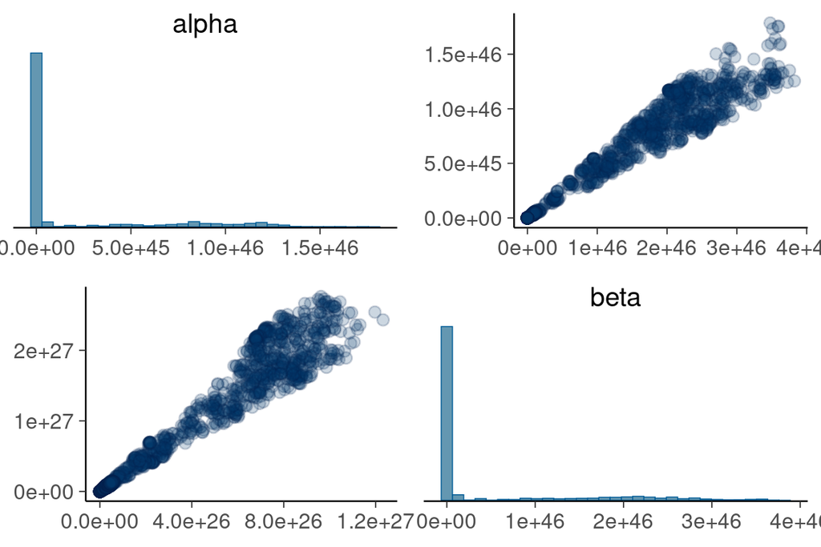

Figure 2

```r
mcmc_pairs(as_draws_array(draws), pars = c("alpha", "beta"),
           off_diag_args = list(alpha = 0.2))
```

## 2.4 Stan compiler pedantic check

The above diagnostics are applicable with any probabilistic programming framework. Stan compiler can also recognize some common problems. By default the pedantic mode is not enabled, but we can use option `pedantic = TRUE` at compilation time, or after compilation with the `check_syntax` method.

```r
mod_logit$check_syntax(pedantic = TRUE)
```

The pedantic check correctly warns that `alpha` and `beta` don’t have priors.

## 2.5 A fixed model with proper priors

We add proper weak priors and rerun inference.

```r
code_logit2 <- root("problems", "logit_glm2.stan")
```

```r
print_stan_file(code_logit2)
```

```stan
// logistic regression
data {
  int<lower=0> N;
  int<lower=0> M;
  array[N] int<lower=0,upper=1> y;
  matrix[N,M] x;
}
parameters {
  real alpha;
  vector[M] beta;
}
model {
  alpha ~ normal(0,10);
  beta ~ normal(0,10);
  y ~ bernoulli_logit_glm(x, alpha, beta);
}
```

Sample

```r
mod_logit2 <- cmdstan_model(stan_file = code_logit2)
fit_logit2 <- mod_logit2$sample(data = data_logit, seed = SEED, refresh = 0)
```

## 2.6 Convergence diagnostics

There were no convergence warnings. We can also explicitly check the inference diagnostics:

```r
fit_logit2$diagnostic_summary()
```

```
$num_divergent
[1] 0 0 0 0

$num_max_treedepth
[1] 0 0 0 0

$ebfmi
[1] 1.088640 1.205378 1.011549 1.004046
```

We check $\widehat{R}$ end ESS values, which in this case all look good.

```r
draws <- as_draws_rvars(fit_logit2$draws())
summarize_draws(draws)
```

```
# A tibble: 3 × 10
  variable  mean median    sd   mad    q5   q95  rhat ess_bulk ess_tail
  <chr>    <dbl>  <dbl> <dbl> <dbl> <dbl> <dbl> <dbl>    <dbl>    <dbl>
1 lp__      -2.6   -2.3   1.0  0.79  -4.7  -1.6  1.00    1231.    1462.
2 alpha      6.1    5.8   2.9  2.9    1.9  11.   1.0      862.     907.
3 beta      15.    14.    6.1  6.2    5.3  26.   1.0      839.     979.
```

The following figure shows the more reasonable marginal histograms and joint scatterplots of the posterior sample.

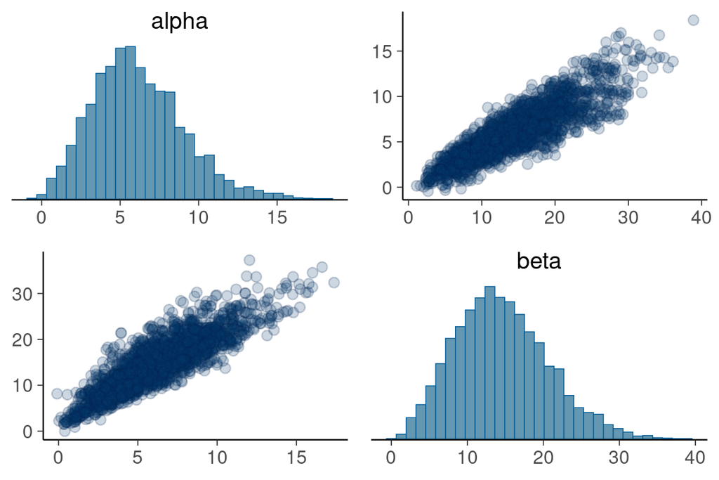

Figure 3

```r
mcmc_pairs(as_draws_array(draws), pars = c("alpha", "beta"),
           off_diag_args = list(alpha = 0.2))
```

# 3 A model with unused parameter

When writing and editing models, a common mistake is to declare a parameter, but not use it in the model. If the parameter is not used at all, it doesn’t have proper prior and the likelihood doesn’t provide information about that parameter, and thus the posterior along that parameter is improper. We use the previous logistic regression model with proper priors on `alpha` and `beta`, but include extra parameter declaration `real gamma`.

## 3.1 Model

```r
code_logit3 <- root("problems", "logit_glm3.stan")
```

```r
print_stan_file(code_logit3)
```

```stan
// logistic regression
data {
  int<lower=0> N;
  int<lower=0> M;
  array[N] int<lower=0,upper=1> y;
  matrix[N,M] x;
}
parameters {
  real alpha;
  vector[M] beta;
  real gamma; // intentionally not used in the model
}
model {
  alpha ~ normal(0,1);
  beta ~ normal(0,1);
  y ~ bernoulli_logit_glm(x, alpha, beta);
}
```

Sample

```r
mod_logit3 <- cmdstan_model(stan_file = code_logit3)
fit_logit3 <- mod_logit3$sample(data = data_logit, seed = SEED, refresh = 0)
```

## 3.2 Convergence diagnostics

There is sampler warning. We can also explicitly call inference diagnostics:

```r
fit_logit3$diagnostic_summary()
```

```
$num_divergent
[1] 0 0 0 0

$num_max_treedepth
[1] 432 409 391 435

$ebfmi
[1] 1.200907 1.383493 1.207598 1.316549
```

Instead of increasing `max_treedepth`, we check the other convergence diagnostics.

```r
draws <- as_draws_rvars(fit_logit3$draws())
summarize_draws(draws)
```

```
# A tibble: 4 × 10
  variable     mean   median      sd     mad       q5     q95  rhat ess_bulk ess_tail
  <chr>       <dbl>    <dbl>   <dbl>   <dbl>    <dbl>   <dbl> <dbl>    <dbl>    <dbl>
1 lp__     -6.6e+ 0 -6.3e+ 0 1.0e+ 0 7.2e- 1 -8.6e+ 0 -5.6e 0   1.0   1951.     2393.
2 alpha     3.4e- 1  3.3e- 1 6.1e- 1 6.2e- 1 -6.4e- 1  1.3e 0   1.0   3532.     2768.
3 beta      1.3e+ 0  1.2e+ 0 7.6e- 1 7.7e- 1  3.7e- 2  2.6e 0   1.0   3213.     2971.
4 gamma    -6.0e+19  1.4e+18 1.3e+20 4.9e+19 -3.5e+20  4.4e19   2.4      5.3      16.
```

$\widehat{R}$, Bulk-ESS, and Tail-ESS look good for `alpha` and `beta, but really bad for`gamma`, clearly pointing where to look for problems in the model code. The histogram of`gamma` posterior draws show huge magnitude of values (values larger than $10^{20}$) indicating improper posterior.

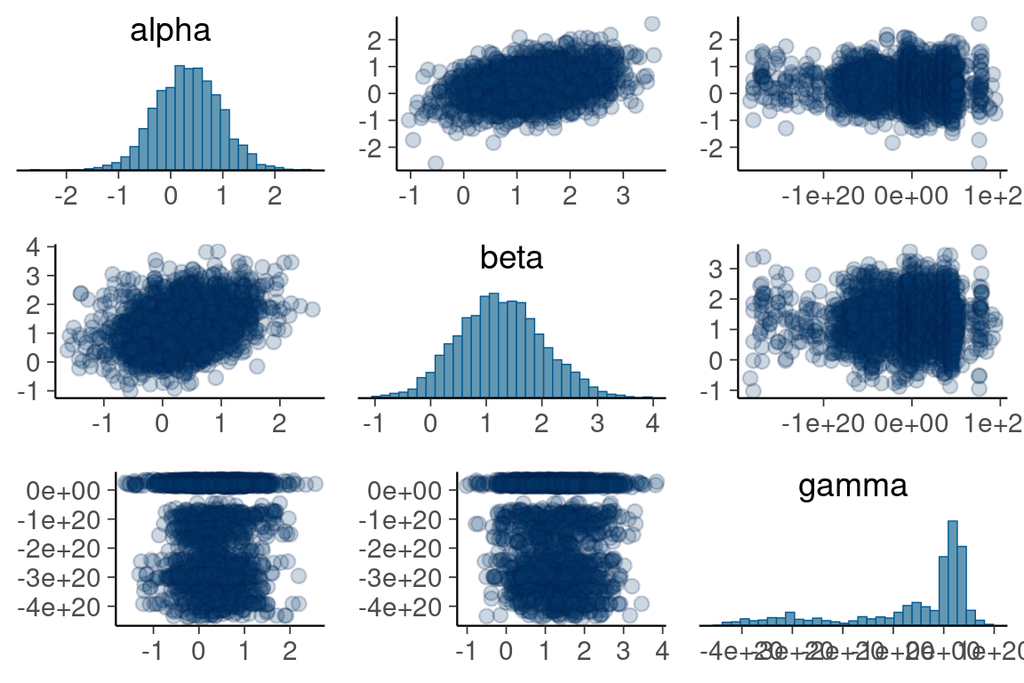

Figure 4

```r
mcmc_pairs(as_draws_array(draws), pars = c("alpha", "beta", "gamma"),
           off_diag_args = list(alpha = 0.2))
```

Non-mixing is well diagnosed by $\widehat{R}$ and ESS, but the following Figure shows one of the rare cases where trace plots are useful to illustrate the type of non-mixing in case of improper uniform posterior for one the parameters.

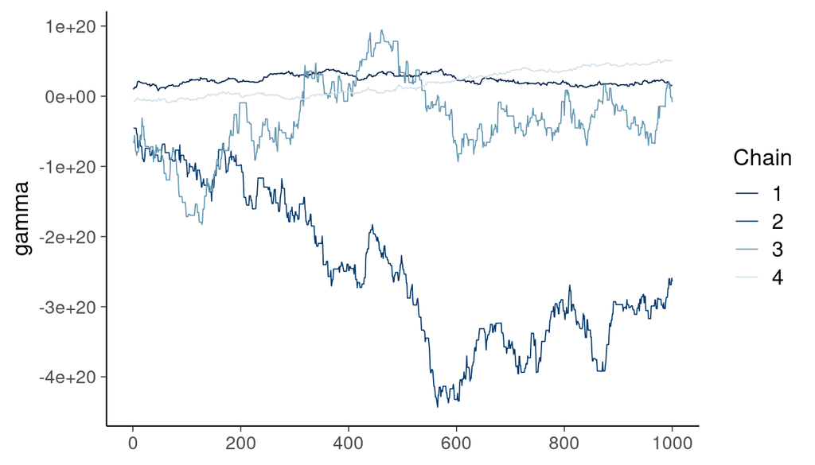

Figure 5

```r
mcmc_trace(as_draws_array(draws), pars = c("gamma"))
```

## 3.3 Stan compiler pedantic check

Stan compiler pedantic check also recognizes that parameter `gamma` was declared but was not used in the density calculation.

```r
mod_logit3$check_syntax(pedantic = TRUE)
```

# 4 A posterior with two parameters competing

Sometimes the models have two or more parameters that have similar or exactly the same role. We illustrate this by adding an extra column to the previous data matrix. Sometimes the data matrix is augmented with a column of 1’s to present the intercept effect. In this case that is redundant as our model has the explicit intercept term `alpha`, and this redundancy will lead to problems.

## 4.1 Data

```r
M <- 2
N <- 1000
x <- matrix(c(rep(1, N), sort(rnorm(N))), ncol = M)
y <- ((x[, 1] + rnorm(N) / 2) > 0) + 0
data_logit4 <- list(M = M, N = N, x = x, y = y)
```

## 4.2 Model

We use the previous logistic regression model with proper priors (and no extra `gamma`).

```r
code_logit2 <- root("problems", "logit_glm2.stan")
```

```r
print_stan_file(code_logit2)
```

```stan
// logistic regression
data {
  int<lower=0> N;
  int<lower=0> M;
  array[N] int<lower=0,upper=1> y;
  matrix[N,M] x;
}
parameters {
  real alpha;
  vector[M] beta;
}
model {
  alpha ~ normal(0,10);
  beta ~ normal(0,10);
  y ~ bernoulli_logit_glm(x, alpha, beta);
}
```

Sample

```r
mod_logit4 <- cmdstan_model(stan_file = code_logit2)
fit_logit4 <- mod_logit4$sample(data = data_logit4, seed = SEED, refresh = 0)
```

The Stan sampling time per chain with the original data matrix was less than 0.1s per chain. Now the Stan sampling time per chain is several seconds, which is suspicious. There are no automatic convergence diagnostic warnings and checking other diagnostics don’t show anything really bad.

## 4.3 Convergence diagnostics

```r
fit_logit4$diagnostic_summary()
```

```
$num_divergent
[1] 0 0 0 0

$num_max_treedepth
[1] 0 0 0 0

$ebfmi
[1] 1.0913332 1.0802625 1.0307895 0.9725048
```

```r
draws <- as_draws_rvars(fit_logit4$draws())
summarize_draws(draws)
```

```
# A tibble: 4 × 10
  variable   mean median    sd   mad     q5    q95  rhat ess_bulk ess_tail
  <chr>     <dbl>  <dbl> <dbl> <dbl>  <dbl>  <dbl> <dbl>    <dbl>    <dbl>
1 lp__     -79.   -79.    1.3   1.0  -82.   -78.     1.0    1243.    1866.
2 alpha      2.3    2.3   7.4   7.5   -9.5   15.     1.0    1014.     867.
3 beta[1]    2.0    2.0   7.4   7.6  -10.    14.     1.0    1013.     883.
4 beta[2]    0.24   0.25  0.26  0.26  -0.17   0.65   1.0    1586.    1614.
```

ESS estimates are above the recommended diagnostic thresholds (Vehtari et al. 2021), but lower than what we would expect in general from Stan for such a lower dimensional problem.

The following figure shows marginal histograms and joint scatterplots, and we can see that `alpha` and `beta[1]` are highly correlated.

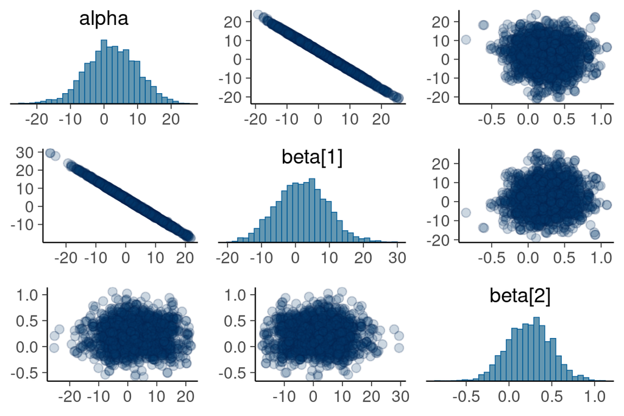

Figure 6

```r
mcmc_pairs(as_draws_array(draws), pars = c("alpha", "beta[1]", "beta[2]"),
           off_diag_args = list(alpha = 0.2))
```

We can compute the correlation.

```r
cor(as_draws_matrix(draws)[, c("alpha", "beta[1]")])[1, 2]
```

```
[1] -0.9992898
```

The numerical value for the correlation is $-0.999$. The correlation close to 1 can happen also from other reasons (see the next example), but one possibility is that parameters have similar role in the model. Here the reason is the constant column in $x$, which we put there for the demonstration purposes. We may a have constant column, for example, if the predictor matrix is augmented with the intercept predictor, or if the observed data or subdata used in the specific analysis happens to have only one unique value.

## 4.4 Stan compiler pedantic check

Stan compiler pedantic check examining the code can’t recognize this issue, as the problem depends also on the data.

```r
mod_logit4$check_syntax(pedantic = TRUE)
```

# 5 A posterior with very high correlation

In the previous example the two parameters had the same role in the model, leading to high posterior correlation. High posterior correlations are common also in linear models when the predictor values are far from 0. We illustrate this with a linear regression model for the summer temperature in Kilpisjärvi, Finland, 1952–2013. We use the year as the covariate $x$ without centering it.

## 5.1 Data

The data are Kilpisjärvi summer month temperatures 1952-2013 measured by Finnish Meteorological Institute.

```r
data_kilpis <- read.delim(root("problems/data", "kilpisjarvi-summer-temp.csv"), sep = ";")
data_lin <- list(M = 1,
                 N = nrow(data_kilpis),
                 x = matrix(data_kilpis$year, ncol = 1),
                 y = data_kilpis[, 5])
```

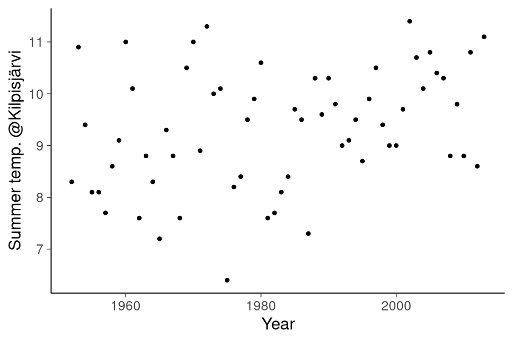

Figure 7

```r
data.frame(data_lin) |>
  ggplot(aes(x, y)) +
  geom_point(size = 1) +
  labs(y = 'Summer temp. @Kilpisjärvi', x = "Year") +
  guides(linetype = "none")
```

## 5.2 Model

We use the following Stan linear regression model

```r
code_lin <- root("problems", "linear_glm_kilpis.stan")
```

```r
print_stan_file(code_lin)
```

```stan
// logistic regression
data {
  int<lower=0> N;
  int<lower=0> M;
  vector[N] y;
  matrix[N,M] x;
}
parameters {
  real alpha;
  vector[M] beta;
  real<lower=0> sigma;
}
model {
  alpha ~ normal(0, 100);
  beta ~ normal(0, 100);
  sigma ~ normal(0, 1);
  y ~ normal_id_glm(x, alpha, beta, sigma);
}
```

```r
mod_lin <- cmdstan_model(stan_file = code_lin)
fit_lin <- mod_lin$sample(data = data_lin, seed = SEED, refresh = 0)
```

## 5.3 Convergence diagnostics

Stan gives a warning: There were X transitions after warmup that exceeded the maximum treedepth. As in the previous example, there are no other warnings.

```r
fit_lin$diagnostic_summary()
```

```
$num_divergent
[1] 0 0 0 0

$num_max_treedepth
[1]  0  0 15  0

$ebfmi
[1] 0.9888201 0.9097830 1.0498057 1.0725453
```

```r
draws <- as_draws_rvars(fit_lin$draws())
summarize_draws(draws)
```

```
# A tibble: 4 × 10
  variable    mean  median      sd     mad       q5     q95  rhat ess_bulk ess_tail
  <chr>      <dbl>   <dbl>   <dbl>   <dbl>    <dbl>   <dbl> <dbl>    <dbl>    <dbl>
1 lp__     -38.    -38.     1.3     0.98   -41.     -37.      1.0    1127.    1156.
2 alpha    -31.    -31.    16.     15.     -57.      -5.3     1.0    1021.    1232.
3 beta       0.020   0.020  0.0080  0.0076   0.0074   0.034   1.0    1021.    1232.
4 sigma      1.1     1.1    0.10    0.100    0.97     1.3     1.0    1259.    1236.
```

ESS estimates are above the diagnostic threshold, but lower than we would expect for such a low dimensional model, unless there are strong posterior correlations. The following Figure shows the marginal histograms and joint scatterplot for `alpha` and `beta[1]`, which shows they are very highly correlated.

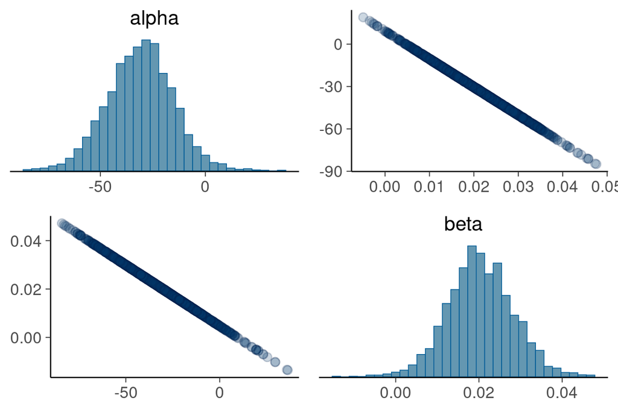

Figure 8

```r
mcmc_pairs(as_draws_array(draws), pars = c("alpha", "beta"),
           off_diag_args = list(alpha = 0.2))
```

Here the reason is that the $x$ values are in the range 1952–2013, and the intercept `alpha` denotes the temperature at year 0, which is very far away from the range of observed $x$. If the intercept `alpha` changes, the slope `beta` needs to change too. The high correlation makes the inference slower, and we can make it faster by centering $x$. Here we simply subtract 1982.5 from the predictor `year`, so that the mean of $x$ is 0. We could also include the centering and back transformation to Stan code.

## 5.4 Centered data

```r
data_lin <- list(
  M = 1,
  N = nrow(data_kilpis),
  x = matrix(data_kilpis$year - 1982.5, ncol = 1),
  y = data_kilpis[, 5]
)
```

```r
fit_lin <- mod_lin$sample(data = data_lin, seed = SEED, refresh = 0)
```

## 5.5 Convergence diagnostics

We check the diagnostics

```r
fit_lin$diagnostic_summary()
```

```
$num_divergent
[1] 0 0 0 0

$num_max_treedepth
[1] 0 0 0 0

$ebfmi
[1] 1.045172 1.039249 1.048480 1.096556
```

```r
draws <- as_draws_rvars(fit_lin$draws())
summarize_draws(draws)
```

```
# A tibble: 4 × 10
  variable    mean  median     sd    mad       q5     q95  rhat ess_bulk ess_tail
  <chr>      <dbl>   <dbl>  <dbl>  <dbl>    <dbl>   <dbl> <dbl>    <dbl>    <dbl>
1 lp__     -38.    -38.    1.3    1.0    -41.     -37.     1.00    1903.    2526.
2 alpha      9.3     9.3   0.15   0.14     9.1      9.6    1.0     3521.    2726.
3 beta       0.020   0.020 0.0081 0.0080   0.0070   0.034  1.00    3965.    2755.
4 sigma      1.1     1.1   0.10   0.100    0.97     1.3    1.0     3055.    2502.
```

The following figure shows the scatter plot.

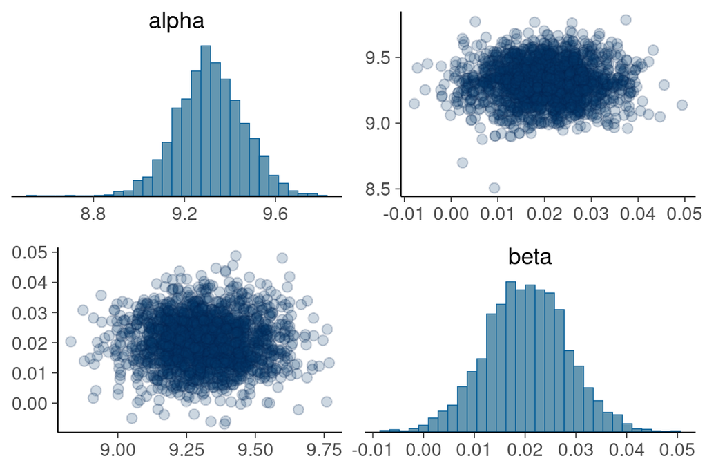

Figure 9

```r
mcmc_pairs(as_draws_array(draws), pars = c("alpha", "beta"),
           off_diag_args = list(alpha = 0.2))
```

With this change, there is no posterior correlation, Bulk-ESS estimates are 3 times bigger, and the mean time per chain goes from 1.3s to less than 0.05s; that is, we get 2 orders of magnitude faster inference. In a bigger problems this could correspond to reduction of computation time from 24 hours to less than 20 minutes.

# 6 A bimodal posterior

Bimodal distributions can arise from many reasons as in mixture models or models with non-log-concave likelihoods or priors (that is, with distributions with thick tails). We illustrate the diagnostics revealing the multimodal posterior. We use a simple toy problem with $t$ model and data that is not from a $t$ distribution, but from a mixture of two normal distributions

## 6.1 Data

Bimodally distributed data

```r
N <- 20
y <- c(rnorm(N / 2, mean = -5, sd = 1), rnorm(N / 2, mean = 5, sd = 1))
data_tt <- list(N = N, y = y)
```

## 6.2 Model

Unimodal Student’s $t$ model:

```r
code_tt <- root("problems", "student.stan")
```

```r
print_stan_file(code_tt)
```

```stan
// student-student model
data {
  int<lower=0> N;
  vector[N] y;
}
parameters {
  real mu;
}
model {
  mu ~ student_t(4, 0, 100);
  y ~ student_t(4, mu, 1);
}
```

Sample

```r
mod_tt <- cmdstan_model(stan_file = code_tt)
fit_tt <- mod_tt$sample(data = data_tt, seed = SEED, refresh = 0)
```

## 6.3 Convergence diagnostics

We check the diagnostics

```r
fit_tt$diagnostic_summary()
```

```
$num_divergent
[1] 0 0 0 0

$num_max_treedepth
[1] 0 0 0 0

$ebfmi
[1] 1.0855996 1.2158209 0.9634865 1.0107784
```

```r
draws <- as_draws_rvars(fit_tt$draws())
summarize_draws(draws)
```

```
# A tibble: 2 × 10
  variable   mean median    sd   mad    q5   q95  rhat ess_bulk ess_tail
  <chr>     <dbl>  <dbl> <dbl> <dbl> <dbl> <dbl> <dbl>    <dbl>    <dbl>
1 lp__     -84.   -83.    0.86  0.74 -85.  -83.    1.2     12.      118.
2 mu        -0.32  -0.20  4.2   6.2   -5.0   4.4   1.7      6.1     200.
```

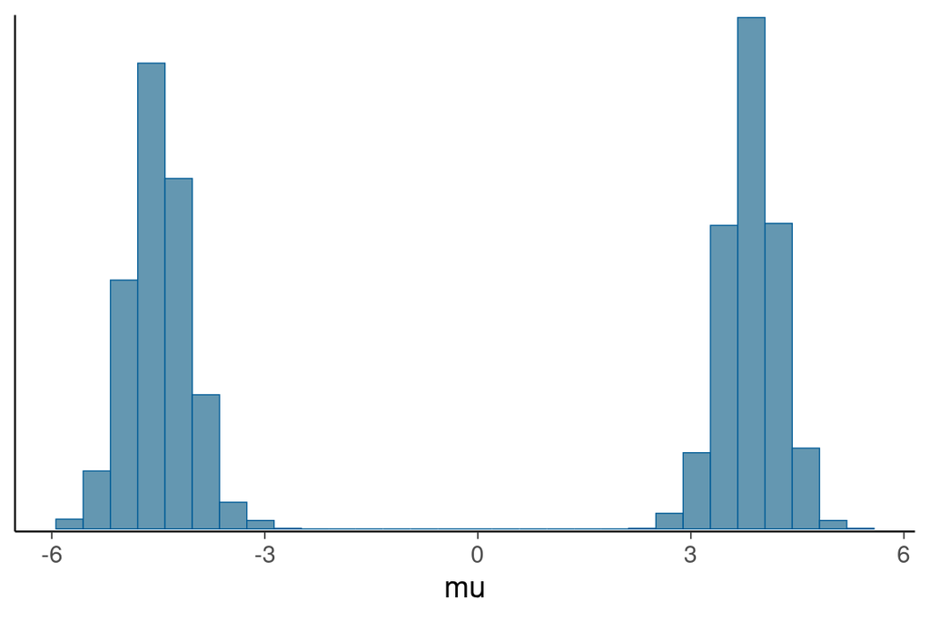

Figure 10

```r
mcmc_hist(as_draws_array(draws), pars = c("mu"))
```

# 7 Easy bimodal posterior

If the modes in the bimodal distribution are not strongly separated, MCMC can jump from one mode to another and there are no convergence issues.

```r
N <- 20
y <- c(rnorm(N / 2, mean = -3, sd = 1), rnorm(N / 2, mean = 3, sd = 1))
data_tt <- list(N = N, y = y)
```

```r
fit_tt <- mod_tt$sample(data = data_tt, seed = SEED, refresh = 0)
```

## 7.1 Convergence diagnostics

We check the diagnostics

```r
fit_tt$diagnostic_summary()
```

```
$num_divergent
[1] 0 0 0 0

$num_max_treedepth
[1] 0 0 0 0

$ebfmi
[1] 1.274083 1.338079 1.268666 1.310952
```

```r
draws <- as_draws_rvars(fit_tt$draws())
summarize_draws(draws)
```

```
# A tibble: 2 × 10
  variable  mean median    sd   mad    q5   q95  rhat ess_bulk ess_tail
  <chr>    <dbl>  <dbl> <dbl> <dbl> <dbl> <dbl> <dbl>    <dbl>    <dbl>
1 lp__     -60.   -59.   0.60  0.52 -61.  -59.    1.0    1013.    1023.
2 mu         1.0    1.2  1.1   1.1   -1.0   2.5   1.0     866.     682.
```

Two modes are visible.

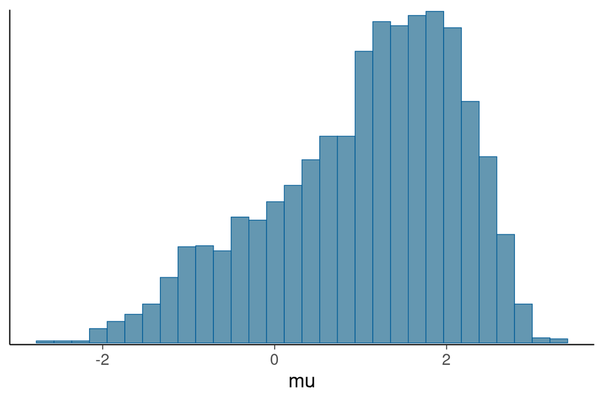

Figure 11

```r
mcmc_hist(as_draws_array(draws), pars = c("mu"))
```

Trace plot is not very useful. It shows the chains are jumping between modes, but it’s difficult to see whether the jumps happen often enough and chains are mixing well.

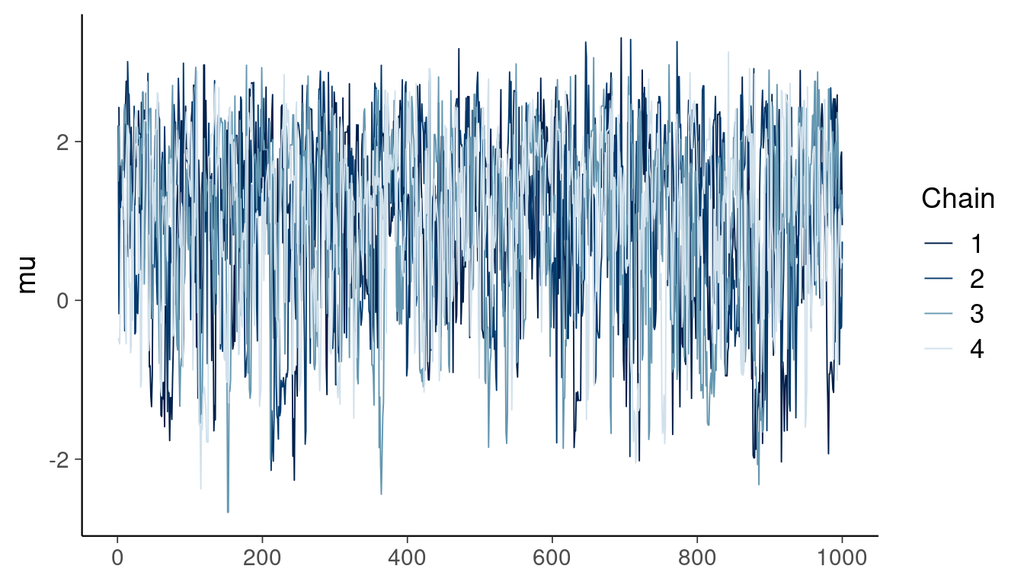

Figure 12

```r
mcmc_trace(as_draws_array(draws), pars = c("mu"))
```

Rank ECDF plot (Säilynoja, Bürkner, and Vehtari 2022) indicates good mixing as all chains have their lines inside the envelope (the envelope assumes no autocorrelation, which is the reason to thin the draws here)

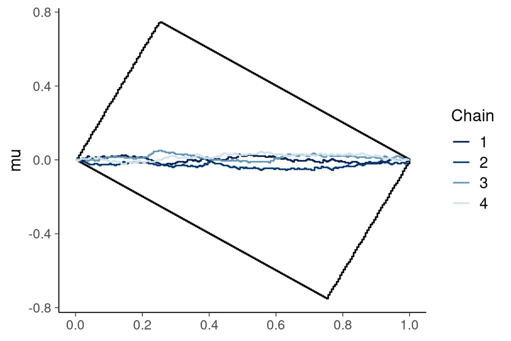

Figure 13

```r
draws |> thin_draws(ndraws(draws) / ess_basic(draws$mu)) |>
  mcmc_rank_ecdf(pars = c("mu"), plot_diff = TRUE)
```

# 8 Initial value issues

MCMC requires some initial values. By default, Stan generates them randomly from [-2,2] in unconstrained space (constraints on parameters are achieved by transformations). Sometimes these initial values can be bad and cause numerical issues. Computers, (in general) use finite number of bits to present numbers and with very small or large numbers, there can be problems of presenting them or there can be significant loss of accuracy.

The data is generated from a Poisson regression model. The Poisson intensity parameter has to be positive and usually the latent linear predictor is exponentiated to be positive (the exponentiation can also be justified by multiplicative effects on Poisson intensity).

We intentionally generate the data so that there are initialization problems, but the same problem is common with real data when the scale of the predictors is large or small compared to the unit scale. The following figure shows the simulated data.

## 8.1 Data

```r
set.seed(SEED)
M <- 1
N <- 20
x <- 1e3 * matrix(c(sort(rnorm(N))), ncol = M)
y <- rpois(N, exp(1e-3 * x[, 1]))
data_pois <- list(M = M, N = N, x = x, y = y)
```

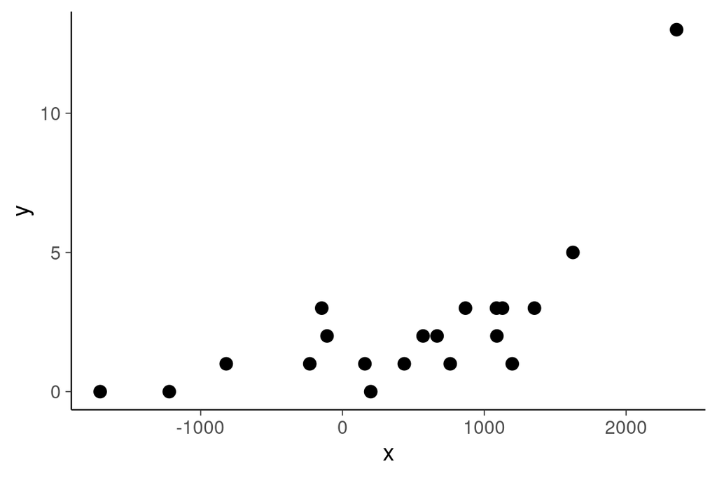

Figure 14

```r
data.frame(data_pois) |>
  ggplot(aes(x, y)) +
  geom_point(size = 3)
```

## 8.2 Model

We use a Poisson regression model with proper priors. The line `poisson_log_glm(x, alpha, beta)` corresponds to a distribution in which the log intensity of the Poisson distribution is modeled with `alpha + beta * x` but is implemented with better computational efficiency.

```r
code_pois <- root("problems", "pois_glm.stan")
```

```r
print_stan_file(code_pois)
```

```stan
// Poisson regression
data {
  int<lower=0> N;
  int<lower=0> M;
  array[N] int<lower=0> y;
  matrix[N,M] x;
}
parameters {
  real alpha;
  vector[M] beta;
}
model {
  alpha ~ normal(0,10);
  beta ~ normal(0,10);
  y ~ poisson_log_glm(x, alpha, beta);
}
```

Sample

```r
mod_pois <- cmdstan_model(stan_file = code_pois)
fit_pois <- mod_pois$sample(data = data_pois, seed = SEED, refresh = 0)
```

We get a lot of warnings:

```
Chain 4 Rejecting initial value:
Chain 4   Log probability evaluates to log(0), i.e. negative infinity.
Chain 4   Stan can't start sampling from this initial value.
```

## 8.3 Convergence diagnostics

We check the diagnostics:

```r
fit_pois$diagnostic_summary()
```

```
$num_divergent
[1] 0 0 0 0

$num_max_treedepth
[1]   2   0 319   0

$ebfmi
[1] 0.016884 1.211112 1.166652 1.186390
```

```r
draws <- as_draws_rvars(fit_pois$draws())
summarize_draws(draws)
```

```
# A tibble: 3 × 10
  variable     mean median      sd     mad       q5    q95  rhat ess_bulk ess_tail
  <chr>       <dbl>  <dbl>   <dbl>   <dbl>    <dbl>  <dbl> <dbl>    <dbl>    <dbl>
1 lp__     -7.7e+41 8.9    2.2e+42 1.3     -1.9e+42 10.0     1.6      6.8      11.
2 alpha     2.7e- 1 0.068  6.5e- 1 0.45    -5.1e- 1  1.3     1.5      7.4      NA
3 beta      1.1e- 2 0.0011 1.7e- 2 0.00030  7.5e- 4  0.041   1.6      6.8      11.
```

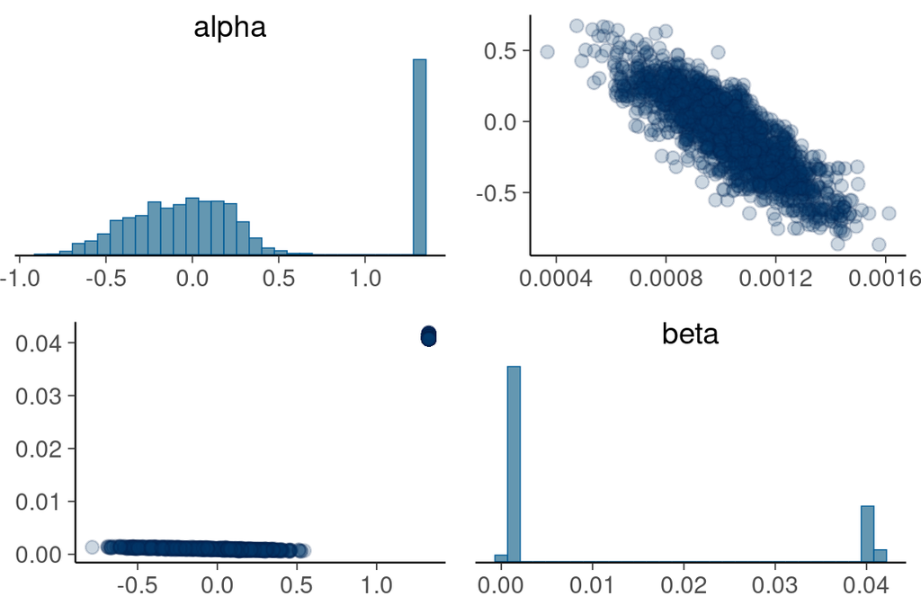

Figure 15

```r
mcmc_pairs(as_draws_array(draws), pars = c("alpha", "beta"),
           off_diag_args = list(alpha = 0.2))
```

The reason for the issue is that the initial values for `beta` are sampled from $(-2, 2)$ and `x` has some large values. If the initial value for `beta` is higher than about 0.3 or lower than $-0.4$, some of the values of `exp(alpha + beta * x)` will overflow to floating point infinity (`Inf`).

## 8.4 Scaled data

Sometimes an easy option is to change the initialization range. For example, in this the sampling succeeds if the initial values are drawn from the range $(-0.001, 0.001)$. Alternatively we can scale `x` to have scale close to unit scale. After this scaling, the computation is fast and all convergence diagnostics look good.

```r
data_pois <- list(M = M, N = N, x = x / 1e3, y = y)
```

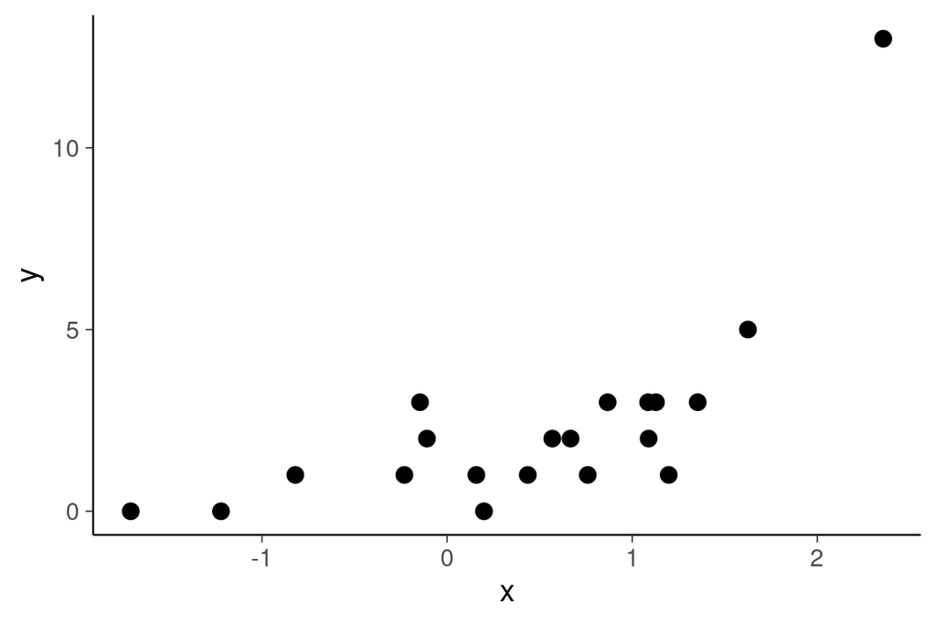

Figure 16

```r
data.frame(data_pois) |>
  ggplot(aes(x, y)) +
  geom_point(size = 3)
```

```r
mod_pois <- cmdstan_model(stan_file = code_pois)
fit_pois <- mod_pois$sample(data = data_pois, seed = SEED, refresh = 0)
```

## 8.5 Convergence diagnostics

We check the diagnostics:

```r
fit_pois$diagnostic_summary()
```

```
$num_divergent
[1] 0 0 0 0

$num_max_treedepth
[1] 0 0 0 0

$ebfmi
[1] 1.094493 1.040770 1.061937 1.146358
```

```r
draws <- as_draws_rvars(fit_pois$draws())
summarize_draws(draws)
```

```
# A tibble: 3 × 10
  variable   mean median    sd   mad    q5   q95  rhat ess_bulk ess_tail
  <chr>     <dbl>  <dbl> <dbl> <dbl> <dbl> <dbl> <dbl>    <dbl>    <dbl>
1 lp__      9.1    9.4    0.99  0.68  7.2  10.     1.0    1029.    1833.
2 alpha    -0.036 -0.029  0.26  0.26 -0.48  0.38   1.0    1051.    1279.
3 beta      1.0    1.0    0.18  0.18  0.70  1.3    1.0     973.    1199.
```

If the initial value warning comes only once, it is possible that MCMC was able to escape the bad region and rest of the inference is ok.

# 9 Thick tailed posterior

We return to the logistic regression example with separable data. Now we use proper, but thick tailed Cauchy prior.

## 9.1 Model

```r
code_logit_glm4 <- root("problems", "logit_glm4.stan")
```

```r
print_stan_file(code_logit_glm4)
```

```stan
// logistic regression
data {
  int<lower=0> N;
  int<lower=0> M;
  array[N] int<lower=0,upper=1> y;
  matrix[N,M] x;
}
parameters {
  real alpha;
  vector[M] beta;
}
model {
  alpha ~ cauchy(0, 10);
  beta ~ cauchy(0, 10);
  y ~ bernoulli_logit_glm(x, alpha, beta);
}
```

Sample

```r
mod_logit_glm4 <- cmdstan_model(stan_file = code_logit_glm4)
fit_logit_glm4 <- mod_logit_glm4$sample(data = data_logit, seed = SEED, refresh = 0)
```

## 9.2 Convergence diagnostics

We check diagnostics

```r
fit_logit_glm4$diagnostic_summary()
```

```
$num_divergent
[1] 0 0 0 0

$num_max_treedepth
[1] 0 0 0 0

$ebfmi
[1] 0.1913679 0.1705309 0.7056304 0.7055436
```

```r
draws <- as_draws_rvars(fit_logit_glm4$draws())
summarize_draws(draws)
```

```
# A tibble: 3 × 10
  variable  mean median    sd   mad    q5   q95  rhat ess_bulk ess_tail
  <chr>    <dbl>  <dbl> <dbl> <dbl> <dbl> <dbl> <dbl>    <dbl>    <dbl>
1 lp__      -4.2   -3.3   2.6   1.6  -9.7  -1.9   1.0     173.      63.
2 alpha     21.    10.   46.    7.9   2.5  73.    1.0     162.      61.
3 beta      51.    24.  112.   19.    6.7 165.    1.0     160.      60.
```

The rounded $\widehat{R}$ values look good, ESS values are low. Looking at the marginal histograms and joint scatterplots of the posterior draws in the following figure show a thick tail.

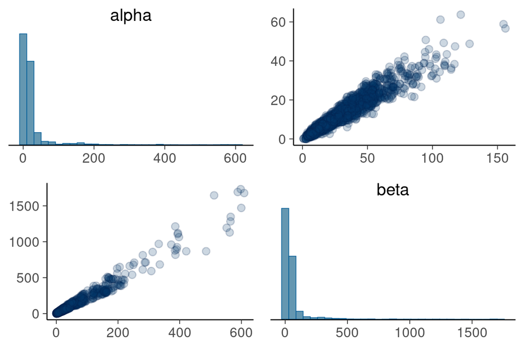

Figure 17

```r
mcmc_pairs(as_draws_array(draws), pars = c("alpha", "beta"),
           off_diag_args = list(alpha = 0.2))
```

The dynamic HMC algorithm used by Stan, along with many other MCMC methods, have problems with such thick tails and mixing is slow.

Rank ECDF plot indicates good mixing as all chains have their lines inside the envelope (the envelope assumes no autocorrelation, which is the reason to thin the draws here)

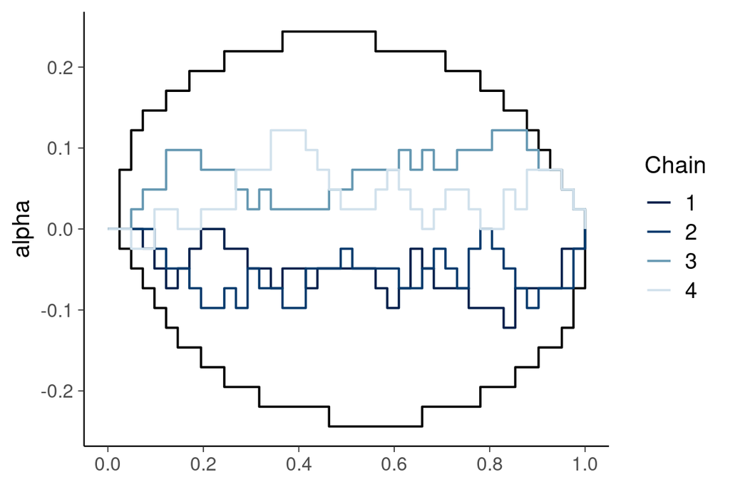

Figure 18

```r
draws |> thin_draws(ndraws(draws) / ess_bulk(draws$alpha)) |>
  mcmc_rank_ecdf(pars = c("alpha"), plot_diff = TRUE)
```

More iterations confirm a reasonable mixing.

```r
fit_logit_glm4 <- mod_logit_glm4$sample(data = data_logit, seed = SEED, refresh = 0,
                                        iter_sampling = 4000)

draws <- as_draws_rvars(fit_logit_glm4$draws())
summarize_draws(draws)
```

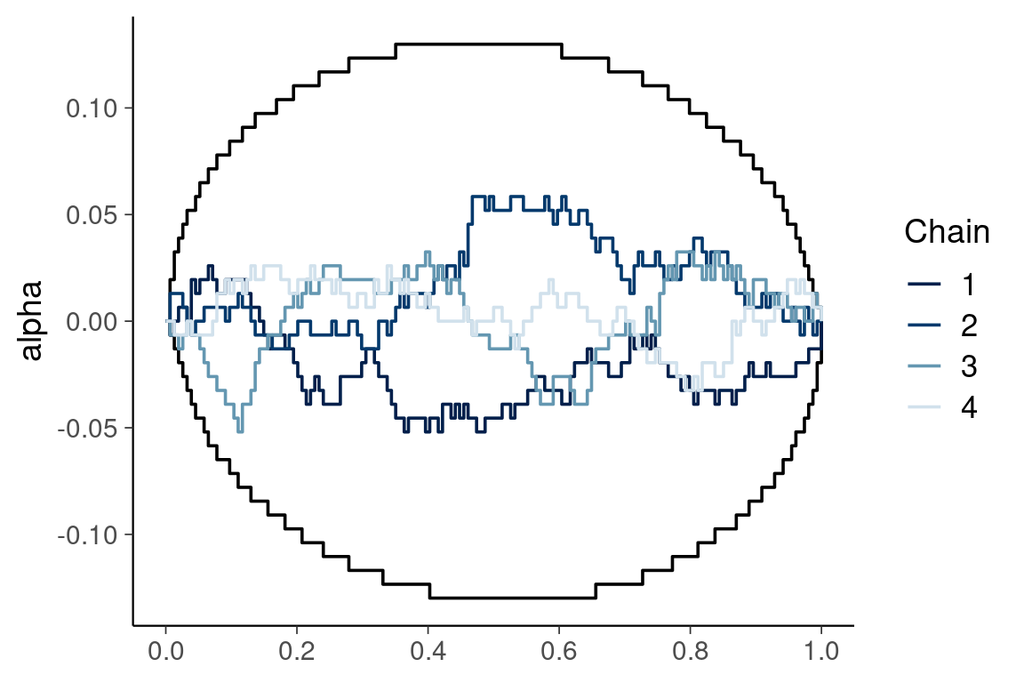

Figure 19

```r
draws |> thin_draws(ndraws(draws) / ess_bulk(draws$alpha)) |>
  mcmc_rank_ecdf(pars = c("alpha"), plot_diff = TRUE)
```

# 10 Funnel

A special case of varying curvature is known as the funnel, based on the shape of the typical set of the distribution. Consider a hierarchical model, $y_i\sim\mathrm{normal}(\mu_{k[i]},\sigma)$ for $i=1,\dots,N$ and group membership variable $k[i]$ which takes on values from 1 through $K$. We shall assume the prior distribution, $\mu_k\sim\mathrm{normal}(\mu_0,\sigma_0),j=1,\dots,J$. When plotted on the scale $\mu_1,\dots,\mu_K, \log\sigma_0$, this prior can be visualized as a having shape of a funnel

```r
data_kilpis <- read.delim(root("problems/data", "kilpisjarvi-summer-temp.csv"), sep = ";")
data_grpy <-list(N = length(data_kilpis$year)*ncol(data_kilpis[,2:4]),
             K = length(data_kilpis$year),
             x = rep(1:length(data_kilpis$year), ncol(data_kilpis[,2:4])),
             y = c(t(t(data_kilpis[,2:4]))))
```

Here is a direct implementation of the hierarchical model in Stan. The parameterization used is also known as centered parameterization.

```r
code_hier_cp <- root("problems", "hier_cp.stan")
```

```r
print_stan_file(code_hier_cp)
```

```stan
data {
  int<lower=0> N;                   // number of observations
  int<lower=0> K;                   // number of groups
  array[N] int<lower=1, upper=K> x; // discrete group indicators
  vector[N] y;                      // real valued observations
}
parameters {
  real mu0;                         // prior mean
  real<lower=0> sigma0;             // prior sd
  vector[K] mu;                     // group means
  real<lower=0> sigma;              // common sd
}
model {
  mu0 ~ normal(10, 10);             // weakly informative prior
  sigma0 ~ normal(0, 10);           // weakly informative prior
  mu ~ normal(mu0, sigma0);         // population prior with unknown parameters
  sigma ~ lognormal(0, .5);         // weakly informative prior
  y ~ normal(mu[x], sigma);         // observation model
}
```

We first try running Stan with its default settings.

```r
SEED <- 48929
mod_hier_cp <- cmdstan_model(stan_file = code_hier_cp)
fit_hier_cp <- mod_hier_cp$sample(data = data_grpy, seed = SEED, refresh = 0)
```

We get a warning that some transitions ended with a divergence. The convergence diagnostics $\widehat{R}$, bulk-ESS, and tail-ESS reveal that the chains are not mixing well:

```r
fit_hier_cp
```

```
 variable    mean  median    sd   mad      q5     q95 rhat ess_bulk ess_tail
   lp__   -173.30 -181.28 42.76 48.98 -232.77 -101.57 1.17       18       85
   mu0       9.32    9.32  0.16  0.18    9.06    9.57 1.03      141      441
   sigma0    0.32    0.27  0.21  0.23    0.07    0.72 1.17       19       36
   mu[1]     9.23    9.26  0.37  0.30    8.56    9.77 1.02      392     1131
   mu[2]     9.46    9.41  0.40  0.29    8.91   10.17 1.02      271      805
   mu[3]     9.33    9.33  0.39  0.30    8.69    9.96 1.02      591     1302
   mu[4]     9.21    9.26  0.40  0.31    8.47    9.78 1.02      416      727
   mu[5]     9.22    9.26  0.39  0.31    8.48    9.78 1.02      302      658
   mu[6]     9.17    9.22  0.41  0.32    8.41    9.74 1.02      322      855
   mu[7]     9.25    9.28  0.37  0.30    8.61    9.81 1.01      461     1212

 # showing 10 of 66 rows (change via 'max_rows' argument or 'cmdstanr_max_rows' option)
```

Plot scatter plot of $\mu_1$ vs $\log\sigma_0$ with divergences shown in red (bayesplot)

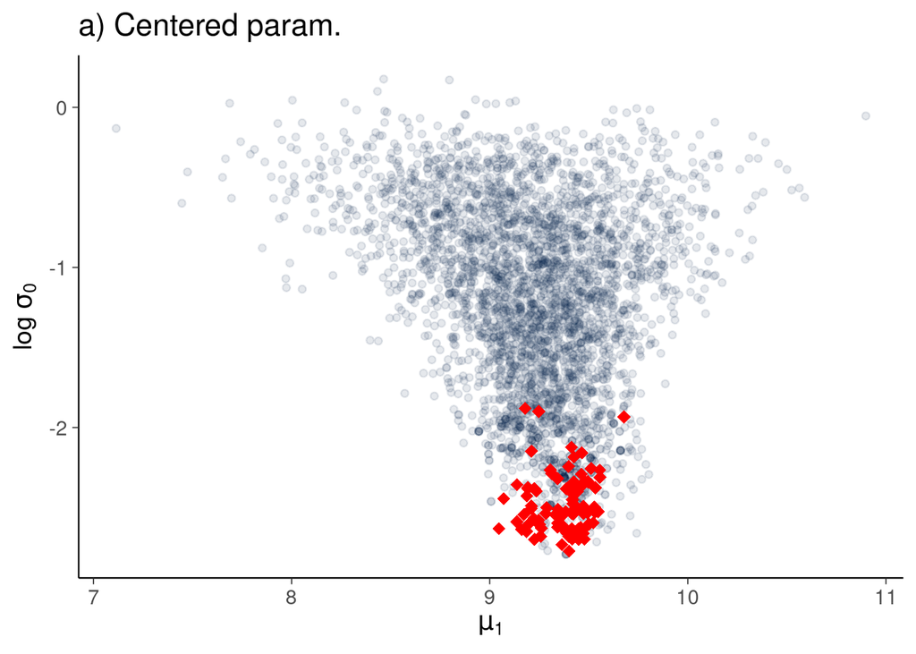

```r
np <- fit_hier_cp$sampler_diagnostics(format="df")|>
  mutate(Chain=.chain,Iteration=.iteration,Parameter="divergent__",Value=divergent__)|>
  select(Chain,Iteration,Parameter,Value)
fit_hier_cp$draws(format="df")|>
  mutate(log_sigma0=log(sigma0))|>
  mcmc_scatter(pars=c("mu[1]","sigma0"),transform=list(sigma0="log"), alpha=0.1, shape=20,
               np=np, np_style = scatter_style_np(div_shape = 18, div_size = 3)) +
  labs(x=TeX(r"($\mu_1$)"), y=TeX(r"($\log\,\sigma_0$)"), title="a) Centered param.")
```

Plot scatter plot of $\mu_1$ vs $\log\sigma_0$ with divergences shown in red (ggplot)

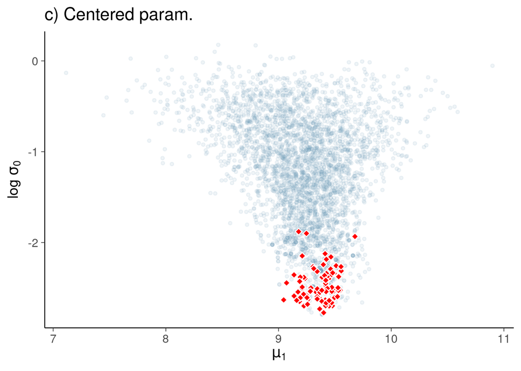

```r
drws <- bind_draws(fit_hier_cp$draws(format="df"), fit_hier_cp$sampler_diagnostics(format="df")) |>
  mutate(log_sigma0=log(sigma0))
p1 <- ggplot(data = NULL, aes(x=`mu[1]`,`log_sigma0`)) +
  geom_point(data = drws |> filter(divergent__==0), shape = 20, color = bayesplot:::get_color("m"), fill = bayesplot:::get_color("lh"), alpha = 0.1, size = 2) +
  geom_point(data = drws |> filter(divergent__==1), shape = 23, fill = "red", color = "white", size = 2) +
  labs(x=TeX(r"($\mu_1$)"), y=TeX(r"($\log\,\sigma_0$)"), title="c) Centered param.")
p1
```

We change the adapt_delta tuning parameter of the NUTS algorithm to force a smaller step size.

```r
fit_hier_cp_999 <- mod_hier_cp$sample(data = data_grpy, seed = SEED, refresh=0, adapt_delta=0.999)
```

However, the convergence diagnostics still indicate serious mixing problems:

```r
fit_hier_cp_999
```

```
 variable    mean  median    sd   mad      q5     q95 rhat ess_bulk ess_tail
   lp__   -180.01 -186.80 40.75 44.39 -235.15 -103.47 1.13       28      128
   mu0       9.30    9.30  0.16  0.16    9.04    9.57 1.03      168      630
   sigma0    0.34    0.31  0.21  0.23    0.07    0.74 1.13       28      134
   mu[1]     9.21    9.24  0.39  0.30    8.50    9.79 1.02      682      827
   mu[2]     9.46    9.40  0.42  0.34    8.90   10.25 1.03      328      789
   mu[3]     9.30    9.30  0.39  0.31    8.65    9.96 1.03      971      840
   mu[4]     9.19    9.22  0.40  0.31    8.48    9.78 1.03      473      696
   mu[5]     9.19    9.23  0.40  0.32    8.45    9.79 1.04      454      954
   mu[6]     9.15    9.20  0.42  0.33    8.37    9.74 1.03      331      681
   mu[7]     9.24    9.25  0.38  0.31    8.57    9.82 1.02      909     1284

 # showing 10 of 66 rows (change via 'max_rows' argument or 'cmdstanr_max_rows' option)
```

Plot scatter plot of $\mu_1$ vs $\log\sigma_0$ with divergences shown in red (bayesplot)

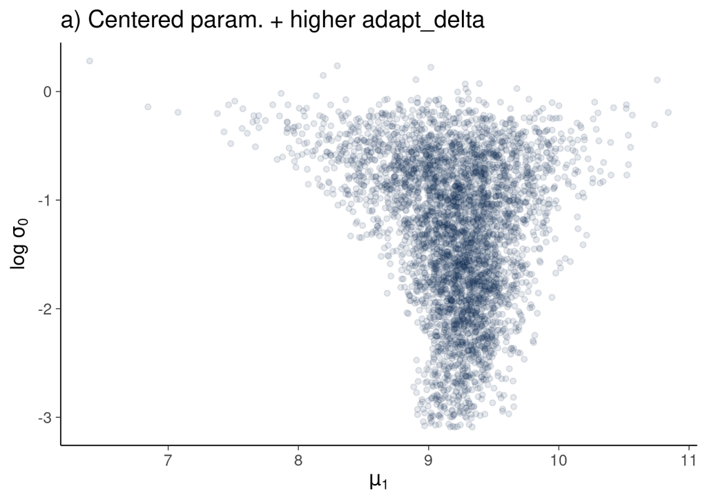

```r
np <- fit_hier_cp_999$sampler_diagnostics(format="df")|>
  mutate(Chain=.chain,Iteration=.iteration,Parameter="divergent__",Value=divergent__)|>
  select(Chain,Iteration,Parameter,Value)
fit_hier_cp_999$draws(format="df")|>
  mutate(log_sigma0=log(sigma0))|>
  mcmc_scatter(pars=c("mu[1]","sigma0"),transform=list(sigma0="log"), alpha=0.1, shape=20,
               np=np, np_style = scatter_style_np(div_shape = 18, div_size = 3)) +
  labs(x=TeX(r"($\mu_1$)"), y=TeX(r"($\log\,\sigma_0$)"), title="a) Centered param. + higher adapt_delta")
```

Plot scatter plot of $\mu_1$ vs $\log\sigma_0$ with divergences shown in red (ggplot)

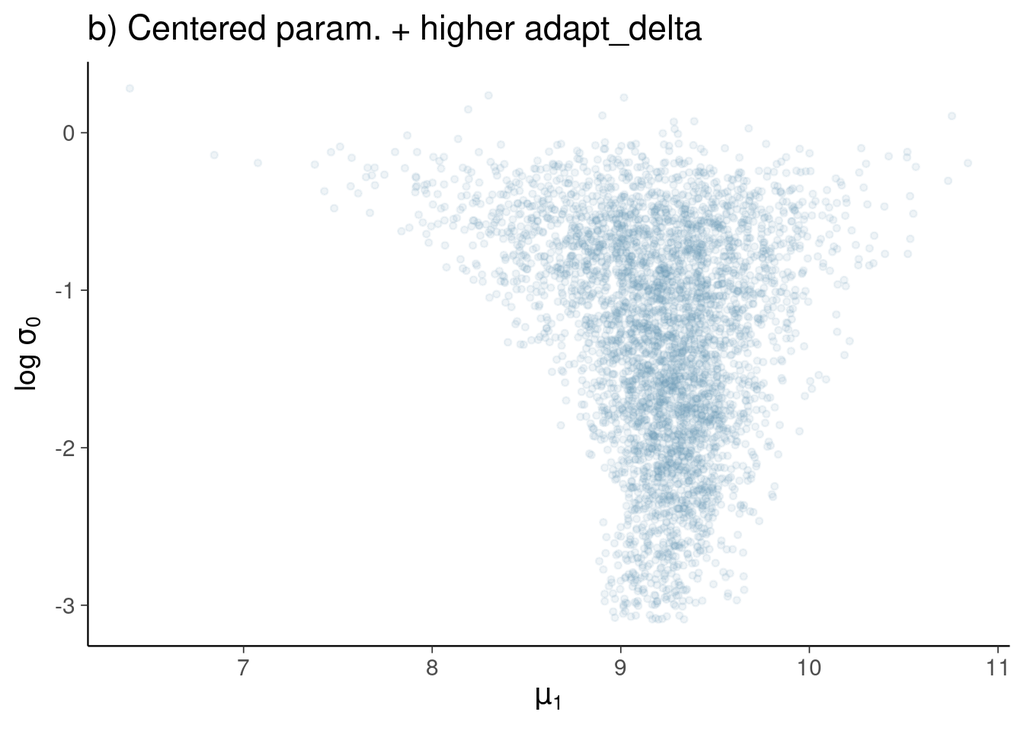

```r
drws <- bind_draws(fit_hier_cp_999$draws(format="df"), fit_hier_cp_999$sampler_diagnostics(format="df")) |>
  mutate(log_sigma0=log(sigma0))
p2 <- ggplot(data = NULL, aes(x=`mu[1]`,`log_sigma0`)) +
  geom_point(data = drws |> filter(divergent__==0), shape = 20, color = bayesplot:::get_color("m"), fill = bayesplot:::get_color("lh"), alpha = 0.1, size = 2) +
  geom_point(data = drws |> filter(divergent__==1), shape = 23, fill = "red", color = "white", size = 2) +
  labs(x=TeX(r"($\mu_1$)"), y=TeX(r"($\log\,\sigma_0$)"), title="b) Centered param. + higher adapt_delta")
p2
```

The usual approach to resolve the funnel problem is to change how the model is parameterized. The so-called non-centered parameterization provides the same model, but the sampling happens in a transformed space that does not have the difficult funnel geometry.

```r
code_hier_ncp <- root("problems", "hier_ncp.stan")
```

```r
print_stan_file(code_hier_ncp)
```

```stan
data {
  int<lower=0> N;                   // number of observations
  int<lower=0> K;                   // number of groups
  array[N] int<lower=1, upper=K> x; // discrete group indicators
  vector[N] y;                      // real valued observations
}
parameters {
  real mu0;                         // prior mean
  real<lower=0> sigma0;             // prior sd
  vector[K] z;                      // latent variable
  real<lower=0> sigma;              // common sd
}
transformed parameters {
  vector[K] mu = mu0 + sigma0 * z;  // group means
}
model {
  mu0 ~ normal(10, 10);             // weakly informative prior
  sigma0 ~ normal(0, 10);           // weakly informative prior
  z ~ normal(0, 1);                 // unit normal
  sigma ~ lognormal(0, .5);         // weakly informative prior
  y ~ normal(mu[x], sigma);         // observation model
}
```

We run Stan with its default settings.

```r
mod_hier_ncp <- cmdstan_model(stan_file = code_hier_ncp)
fit_hier_ncp <- mod_hier_ncp$sample(data = data_grpy, seed = SEED, refresh=0)
```

The convergence diagnostics $\widehat{R}$, bulk-ESS, and tail-ESS look good now.

```r
fit_hier_ncp
```

```
 variable    mean  median   sd  mad      q5     q95 rhat ess_bulk ess_tail
   lp__   -259.64 -259.58 6.98 6.85 -271.16 -248.13 1.00      984     1612
   mu0       9.32    9.32 0.16 0.16    9.06    9.58 1.00     3970     2437
   sigma0    0.33    0.30 0.22 0.24    0.03    0.73 1.00     1358     1880
   z[1]     -0.22   -0.22 0.97 0.97   -1.81    1.40 1.00     5465     2742
   z[2]      0.36    0.37 1.00 1.00   -1.33    1.98 1.00     5659     2746
   z[3]      0.02    0.02 0.98 0.99   -1.57    1.59 1.00     6581     2317
   z[4]     -0.26   -0.29 0.97 0.99   -1.84    1.35 1.00     6780     2817
   z[5]     -0.24   -0.24 0.95 0.97   -1.78    1.33 1.00     7142     2963
   z[6]     -0.33   -0.35 0.97 0.98   -1.88    1.28 1.00     5486     2815
   z[7]     -0.16   -0.15 0.96 0.97   -1.72    1.42 1.00     5771     2806

 # showing 10 of 128 rows (change via 'max_rows' argument or 'cmdstanr_max_rows' option)
```

Plot scatter plot of $\mu_1$ vs $\log\sigma_0$ with divergences shown in red (bayesplot)

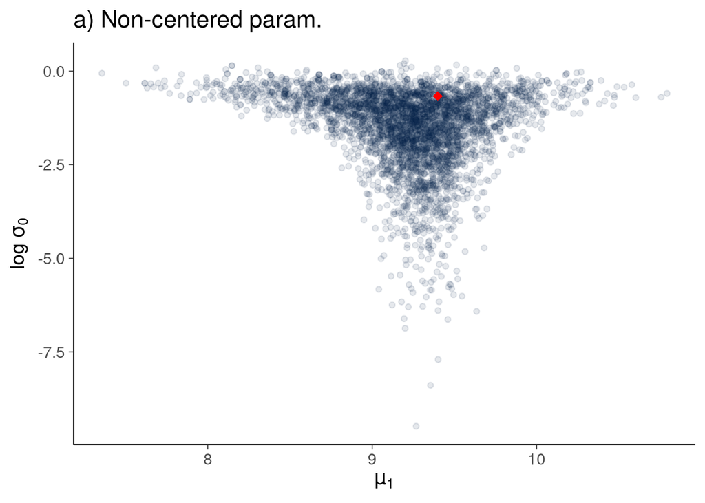

```r
np <- fit_hier_ncp$sampler_diagnostics(format="df")|>
  mutate(Chain=.chain,Iteration=.iteration,Parameter="divergent__",Value=divergent__)|>
  select(Chain,Iteration,Parameter,Value)
fit_hier_ncp$draws(format="df")|>
  mutate(log_sigma0=log(sigma0))|>
  mcmc_scatter(pars=c("mu[1]","sigma0"),transform=list(sigma0="log"), alpha=0.1, shape=20,
               np=np, np_style = scatter_style_np(div_shape = 18, div_size = 3)) +
  labs(x=TeX(r"($\mu_1$)"), y=TeX(r"($\log\,\sigma_0$)"), title="a) Non-centered param.")
```

Plot scatter plot of $\mu_1$ vs $\log\sigma_0$ with divergences shown in red (ggplot)

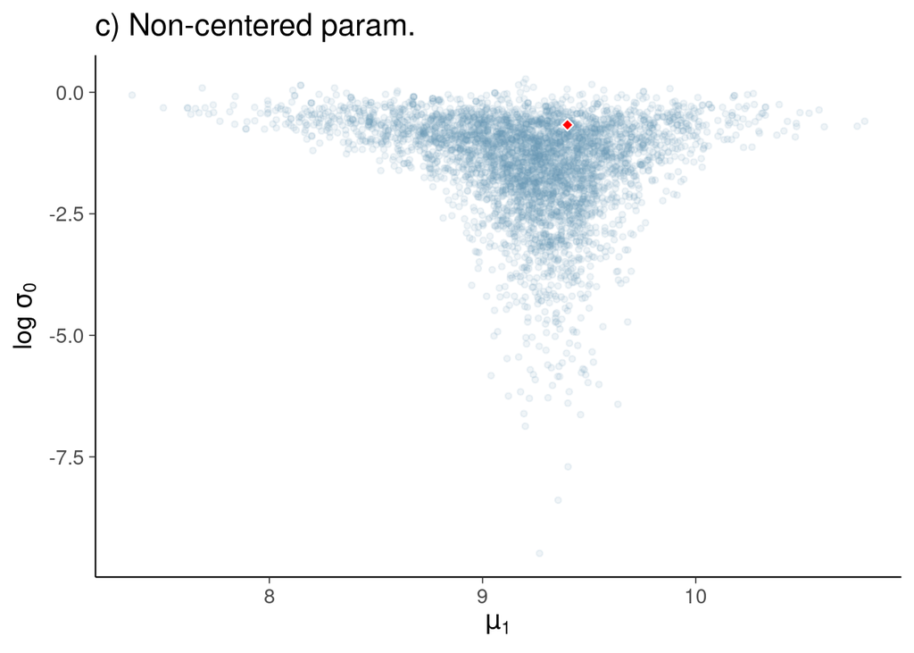

```r
drws <- bind_draws(fit_hier_ncp$draws(format="df"), fit_hier_ncp$sampler_diagnostics(format="df")) |>
  mutate(log_sigma0=log(sigma0))
p3 <- ggplot(data = NULL, aes(x=`mu[1]`,`log_sigma0`)) +
  geom_point(data = drws |> filter(divergent__==0), shape = 20, color = bayesplot:::get_color("m"), fill = bayesplot:::get_color("lh"), alpha = 0.1, size = 2) +
  geom_point(data = drws |> filter(divergent__==1), shape = 23, fill = "red", color = "white", size = 2) +
  labs(x=TeX(r"($\mu_1$)"), y=TeX(r"($\log\,\sigma_0$)"), title="c) Non-centered param.")
p3
```

If we compare the scatter plots side by side, we clearly see that increasing `adapt_delta` and getting rid of divergences did not solve the funnel problem and the posterior estimates with centered parameterization would be biased.

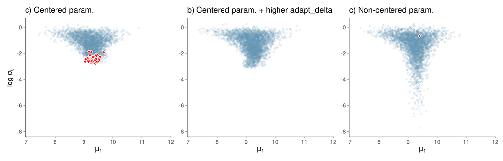

Figure 20

```r
(p1 + p2 + p3) *
  scale_y_continuous(lim=c(-8,0.3)) *
  scale_x_continuous(lim=c(7.2,11.8)) *
  theme(plot.title = element_text(size=16)) +
  plot_layout(axis_titles="collect_y")
```

# 11 Variance parameter that is not constrained to be positive

Demonstration what happens if we forget to constrain a parameter that has to be positive. In Stan the constraint can be added when declaring the parameter as `real<lower=0> sigma;`

## 11.1 Data

We simulated x and y independently from independently from normal(0,1) and normal(0,0.1) respectively. As $N=8$ is small, there will be a lot of uncertainty about the parameters including the scale sigma.

```r
M <- 1
N <- 8
set.seed(SEED)
x <- matrix(rnorm(N), ncol = M)
y <- rnorm(N) / 10
data_lin <- list(M = M, N = N, x = x, y = y)
```

## 11.2 Model

We use linear regression model with proper priors.

```r
code_lin <- root("problems", "linear_glm.stan")
```

```r
print_stan_file(code_lin)
```

```stan
// logistic regression
data {
  int<lower=0> N;
  int<lower=0> M;
  vector[N] y;
  matrix[N,M] x;
}
parameters {
  real alpha;
  vector[M] beta;
  real sigma; // intentionally missing lower=0
}
model {
  alpha ~ normal(0, 1);
  beta ~ normal(0, 1);
  sigma ~ normal(0, 1);
  y ~ normal_id_glm(x, alpha, beta, sigma);
}
```

Sample

```r
mod_lin <- cmdstan_model(stan_file = code_lin)
fit_lin <- mod_lin$sample(data = data_lin, seed = SEED, refresh = 0)
```

We get many times the following warnings

```
Chain 4 Informational Message: The current Metropolis proposal is about to be rejected because of the following issue:
Chain 4 Exception: normal_id_glm_lpdf: Scale vector is -0.747476, but must be positive finite! (in '/tmp/RtmprEP4gg/model-7caa12ce8e405.stan', line 16, column 2 to column 43)
Chain 4 If this warning occurs sporadically, such as for highly constrained variable types like covariance matrices, then the sampler is fine,
Chain 4 but if this warning occurs often then your model may be either severely ill-conditioned or misspecified.
```

Sometimes these warnings appear in early phase of the sampling, even if the model has been correctly defined. Now we have too many of them, which indicates the samples is trying to jump to infeasible values, which here means the negative scale parameter values. Many rejections may lead to biased estimates.

There are some divergences reported, which is also indication that there might be some problem (as divergence diagnostic has an ad hoc diagnostic threshold, there can also be false positive warnings). Other convergence diagnostics are good, but due to many rejection warnings, it is good to check the model code and numerical accuracy of the computations.

## 11.3 Convergence diagnostics

We check diagnostics

```r
fit_lin$diagnostic_summary()
```

```
$num_divergent
[1] 0 3 0 2

$num_max_treedepth
[1] 0 0 0 0

$ebfmi
[1] 0.5917343 0.6731945 0.7169593 0.6044464
```

```r
draws <- as_draws_rvars(fit_lin$draws())
summarize_draws(draws)
```

```
# A tibble: 4 × 10
  variable    mean  median    sd   mad     q5    q95  rhat ess_bulk ess_tail
  <chr>      <dbl>   <dbl> <dbl> <dbl>  <dbl>  <dbl> <dbl>    <dbl>    <dbl>
1 lp__     17.     17.     1.8   1.4   13.    19.      1.0     835.     833.
2 alpha    -0.015  -0.015  0.032 0.027 -0.066  0.036   1.0    2344.    1770.
3 beta     -0.0026 -0.0026 0.031 0.027 -0.052  0.047   1.0    2035.    1270.
4 sigma     0.086   0.077  0.036 0.025  0.049  0.16    1.0    1115.     940.
```

## 11.4 Stan compiler pedantic check

```r
mod_lin$check_syntax(pedantic = TRUE)
```

After fixing the model with proper parameter constraint, MCMC runs without warnings and the sampling efficiency is better. In this specific case, the bias is negligible when running MCMC with the model code without the constraint, but it is difficult to diagnose without running the fixed model.

Fixed model includes <lower=0> constraint for sigma.

```r
code_lin2 <- root("problems", "linear_glm2.stan")
```

```r
print_stan_file(code_lin2)
```

```stan
// logistic regression
data {
  int<lower=0> N;
  int<lower=0> M;
  vector[N] y;
  matrix[N,M] x;
}
parameters {
  real alpha;
  vector[M] beta;
  real<lower=0> sigma;
}
model {
  alpha ~ normal(0, 1);
  beta ~ normal(0, 1);
  sigma ~ normal(0, 1);
  y ~ normal_id_glm(x, alpha, beta, sigma);
}
```

Sample

```r
mod_lin2 <- cmdstan_model(stan_file = code_lin2)
fit_lin2 <- mod_lin2$sample(data = data_lin, seed = SEED, refresh = 0)
```

We check diagnostics

```r
draws2 <- as_draws_rvars(fit_lin2$draws())
summarize_draws(draws2)
```

```
# A tibble: 4 × 10
  variable    mean  median    sd   mad     q5    q95  rhat ess_bulk ess_tail
  <chr>      <dbl>   <dbl> <dbl> <dbl>  <dbl>  <dbl> <dbl>    <dbl>    <dbl>
1 lp__     14.     15.     1.6   1.3   11.    16.      1.0    1017.    1571.
2 alpha    -0.016  -0.015  0.034 0.029 -0.071  0.034   1.0    1873.    1482.
3 beta     -0.0037 -0.0032 0.033 0.026 -0.053  0.047   1.0    2422.    1724.
4 sigma     0.087   0.078  0.036 0.025  0.049  0.15    1.0    1440.    1814.
```

In this specific case, the bias is negligible when running MCMC with the model code without the constraint, but it is difficult to diagnose without running the fixed model.

# References

Säilynoja, Teemu, Paul-Christian Bürkner, and Aki Vehtari. 2022. “Graphical Test for Discrete Uniformity and Its Applications in Goodness-of-Fit Evaluation and Multiple Sample Comparison.” *Statistics and Computing* 32: 1573–375.

Vehtari, Aki, Andrew Gelman, Daniel Simpson, Bob Carpenter, and Paul-Christian Bürkner. 2021. “Rank-Normalization, Folding, and Localization: An Improved $\widehat{R}$ for Assessing Convergence of MCMC (with Discussion).” *Bayesian Analysis* 16 (2): 667–718.

# Licenses

- Code © 2021–2025, Aki Vehtari, licensed under BSD-3.
- Text © 2021–2025, Aki Vehtari, licensed under CC-BY-NC 4.0.